# PAR Inference

Heath Blackmon

2023-11-10

## Background

We would like to be able to determine whether structural changes in the genome (e.g., X autosome fusions) and the evolution of alterantive forms of meiosis (e.g., achiasmatic meiosis) are associated with lineages that have reduced PAR size. However, only a handful of PAR sizes have been documented. A total of seven species have both a chromosomal level assembly and a documented par:

| species | true.par |
| --- | --- |
| human | 2.7 |
| mouse | 0.7 |
| cat | 8.0 |
| dog | 6.4 |
| cattle | 9.6 |
| horse | 1.8 |
| pig | 9.9 |

## Inference Approach

Our idea is to take short read sequencing data and map it to the closest assembled X chromosome. We then plan on using heterozygosity and read depth to infer the portion of the X chromosome that is still recombining. For some data sets this looks like it works incredibly well. For instance below lets look at a species with a relatively large par like cat. Also lets simulate the situation that we will often be in and pretend that we have no cat assembly and instead map the male cat reads to the leopard genome.

### Cat to Leopard

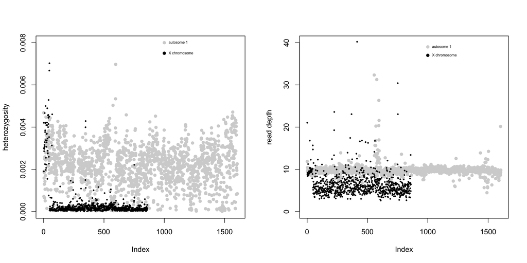

```r
dat <- read.csv("../results/cat-leop.csv")
par(mfcol=c(1,2))
plot(dat$chr1het,pch=16, col="lightgray", ylab= "heterozygosity", ylim=c(0,0.008))
points(dat$chrXhet, pch=16, cex=.5)
points(x=c(1000,1000),y=c(0.008,0.0075), col=c("lightgray","black"),pch=16)
text(x=c(1000,1000),y=c(0.008,0.0075), c("autosome 1", "X chromosome"),pos=4, cex=.5)

plot(dat$chr1dep,pch=16, col="lightgray", ylim=c(0,40),ylab="read depth")
points(dat$chrXdep, pch=16, cex=.5)
points(x=c(1000,1000),y=c(39,37), col=c("lightgray","black"),pch=16)
text(x=c(1000,1000),y=c(39,37), c("autosome 1", "X chromosome"),pos=4, cex=.5)
```

Here we can see a clear signal for the PAR in both heterozygosity and read depth. These points are the mean value in 150kb windows. We can now use a simple heuristic and ask how many windows in this data set have a heterozygosity of at least 75% of that observed on the autosome and a coverage that is at least 75% of what is observed on the autosome.

```r
het.check <- dat$chrXhet > 0.75*mean(dat$chr1het)
cov.check <- dat$chrXdep > 0.75*mean(dat$chr1dep)
cat(paste((sum(het.check & cov.check, na.rm = T) * 150000/ 1000000), "Mb"))
```

```
## 7.65 Mb
```

So our inference for domestic cat would be 7.65 Mb in comparison to the reported value of 8.00. This level of accuracy if it could be replicated for many species would allow us to move forward with comparative analyses. Lets look at another example with a smaller PAR and this time lets assume it is a species with a chromosomal level assembly. For this example we will use human.

### Human to Human

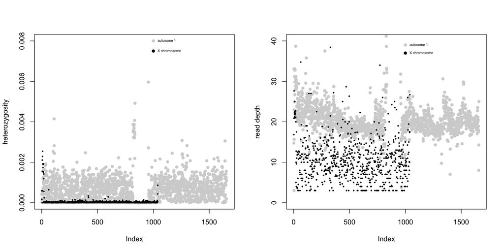

```r
dat <- read.csv("../results/human-self.csv")
par(mfcol=c(1,2))
plot(dat$chr1het,pch=16, col="lightgray", ylab= "heterozygosity", ylim=c(0,0.008))
points(dat$chrXhet, pch=16, cex=.5)
points(x=c(1000,1000),y=c(0.008,0.0075), col=c("lightgray","black"),pch=16)
text(x=c(1000,1000),y=c(0.008,0.0075), c("autosome 1", "X chromosome"),pos=4, cex=.5)

plot(dat$chr1dep,pch=16, col="lightgray", ylim=c(0,40),ylab="read depth")
points(dat$chrXdep, pch=16, cex=.5)
points(x=c(1000,1000),y=c(39,37), col=c("lightgray","black"),pch=16)
text(x=c(1000,1000),y=c(39,37), c("autosome 1", "X chromosome"),pos=4, cex=.5)
```

```r
het.check <- dat$chrXhet > 0.75*mean(dat$chr1het,na.rm=T)
cov.check <- dat$chrXdep > 0.75*mean(dat$chr1dep,na.rm=T)
cat(paste((sum(het.check & cov.check, na.rm = T) * 150000/ 1000000), "Mb"))
```

```
## 2.7 Mb
```

In this case our inference is actually spot on with the reported size of 2.7 Mb.

## Failures

Unfortunately some species are being more challenging. In this next example, we are mapping horse to its own chromosome-level assembly.

### Horse to Horse

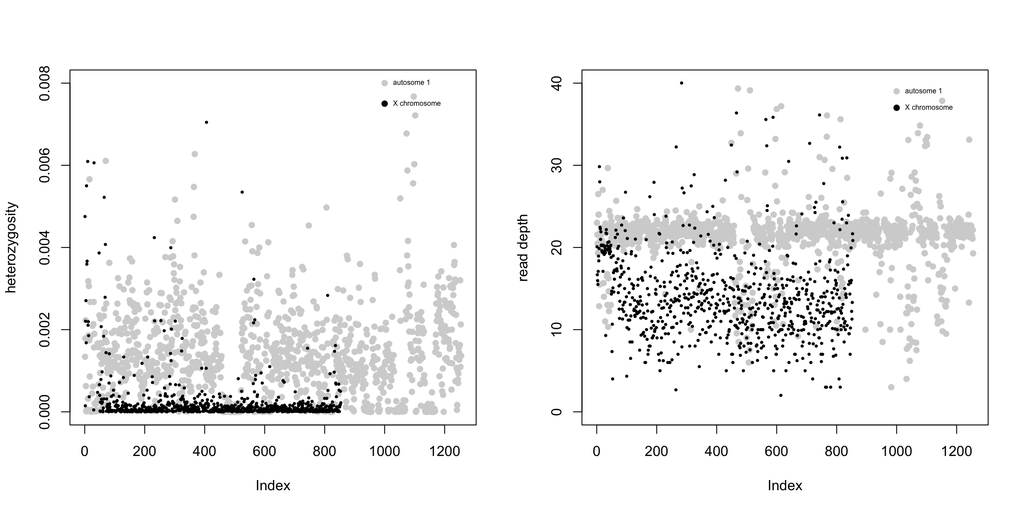

```r
dat <- read.csv("../results/horse-self.csv")
par(mfcol=c(1,2))
plot(dat$chr1het,pch=16, col="lightgray", ylab= "heterozygosity", ylim=c(0,0.008))
points(dat$chrXhet, pch=16, cex=.5)
points(x=c(1000,1000),y=c(0.008,0.0075), col=c("lightgray","black"),pch=16)
text(x=c(1000,1000),y=c(0.008,0.0075), c("autosome 1", "X chromosome"),pos=4, cex=.5)

plot(dat$chr1dep,pch=16, col="lightgray", ylim=c(0,40),ylab="read depth")
points(dat$chrXdep, pch=16, cex=.5)
points(x=c(1000,1000),y=c(39,37), col=c("lightgray","black"),pch=16)
text(x=c(1000,1000),y=c(39,37), c("autosome 1", "X chromosome"),pos=4, cex=.5)
```

```r
het.check <- dat$chrXhet > 0.75*mean(dat$chr1het,na.rm=T)
cov.check <- dat$chrXdep > 0.75*mean(dat$chr1dep,na.rm=T)
cat(paste((sum(het.check & cov.check, na.rm = T) * 150000 / 1000000), "Mb"))
```

```
## 12 Mb
```

While we see a fairly good signal with the heterozygosity data, we predict a significantly larger PAR size thatn is reported for this species.

We also have some species, like mouse, that perform really poorly using our method and any method which we try to apply, which will come as no surprise when you see the data.

### Mouse to Mouse

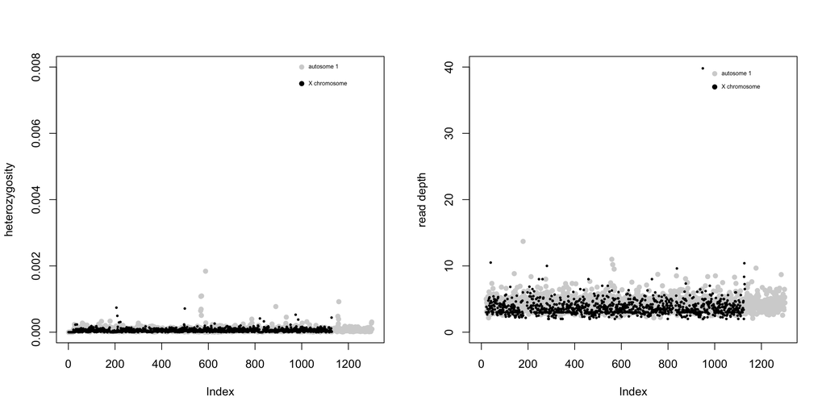

```r
dat <- read.csv("../results/mouse-self.csv")
par(mfcol=c(1,2))
plot(dat$chr1het,pch=16, col="lightgray", ylab= "heterozygosity", ylim=c(0,0.008))
points(dat$chrXhet, pch=16, cex=.5)
points(x=c(1000,1000),y=c(0.008,0.0075), col=c("lightgray","black"),pch=16)
text(x=c(1000,1000),y=c(0.008,0.0075), c("autosome 1", "X chromosome"),pos=4, cex=.5)

plot(dat$chr1dep,pch=16, col="lightgray", ylim=c(0,40),ylab="read depth")
points(dat$chrXdep, pch=16, cex=.5)
points(x=c(1000,1000),y=c(39,37), col=c("lightgray","black"),pch=16)
text(x=c(1000,1000),y=c(39,37), c("autosome 1", "X chromosome"),pos=4, cex=.5)
```

```r
het.check <- dat$chrXhet > 0.75*mean(dat$chr1het,na.rm=T)
cov.check <- dat$chrXdep > 0.75*mean(dat$chr1dep,na.rm=T)
cat(paste((sum(het.check & cov.check, na.rm = T) * 150000 / 1000000), "Mb"))
```

```
## 42.45 Mb
```

This value is proposterous however, it would be easy to discard this one based on a simple requirement like the lack of any divergence in X vs autosome heterozygosity and coverage.